# N0040

# ICD code instances and muscular dystrophy surveillance

## Reading in data

```r
path_using <- "C:/Users/baron063/Desktop/N0040/V20_icd_sum_deid_1_24_2024.sas7bdat"
path_using2 <- "C:/Users/baron063/Desktop/N0040/V21_ICD_Sum_DeID_2_27_2024.sas7bdat"
# path_using_2 <- "C:/Users/baron063/Desktop/N0040/V20_ICD_Sum_DeID_1_24_2024.sav"
data_using <- read_sas(path_using)
V21 <- read_sas(path_using2)
```

## Exploratory data analysis V20

```
[1] "Number of rows in dataset is 1180"
```

```
[1] "Number of columns in dataset is 31"
```

```
 [1] "IndexCaseID"              "Total_Sum_ICD"
 [3] "Sum_G71_0"                "Sum_G71_01"
 [5] "Sum_G71_02"               "Sum_G71_09"
 [7] "Sum_G71_11"               "Sum_359_21"
 [9] "Sum_359_1"                "Sum_359"
[11] "ClinicalMDType"           "CRCCaseStatus"
[13] "ClinicalMDSubType"        "DiagnosisStartDate"
[15] "ICD_Binary_5"             "ICD_Binary_20"
[17] "ICD_Binary_25"            "ICD_Binary_30"
[19] "ICD_Binary_40"            "CaseStatus_Num"
[21] "MDType_UF"                "Binned_2s"
[23] "Binned5s"                 "Binned3s"
[25] "Binned10s"                "DefProb_Poss_Only_2"
[27] "filte_Def_Prob_Poss_1"    "NotElig_filter"
[29] "Filter_exclude_nonCRC"    "DefPro_PossAsymNotElig_3"
[31] "EligibleYesNoPending"
```

```
[1] "Displaying filte_Def_Prob_Poss_1 as a quick table below"
```

```
  0   1
860 320
```

Total_Sum_ICD is the variable of interest? What variable was used to show Case Status as seen in our initial meeting?

Assuming it is filte_Def_Prob_Poss_1.

### Exploring categorical variables

#### CRCCaseStatus

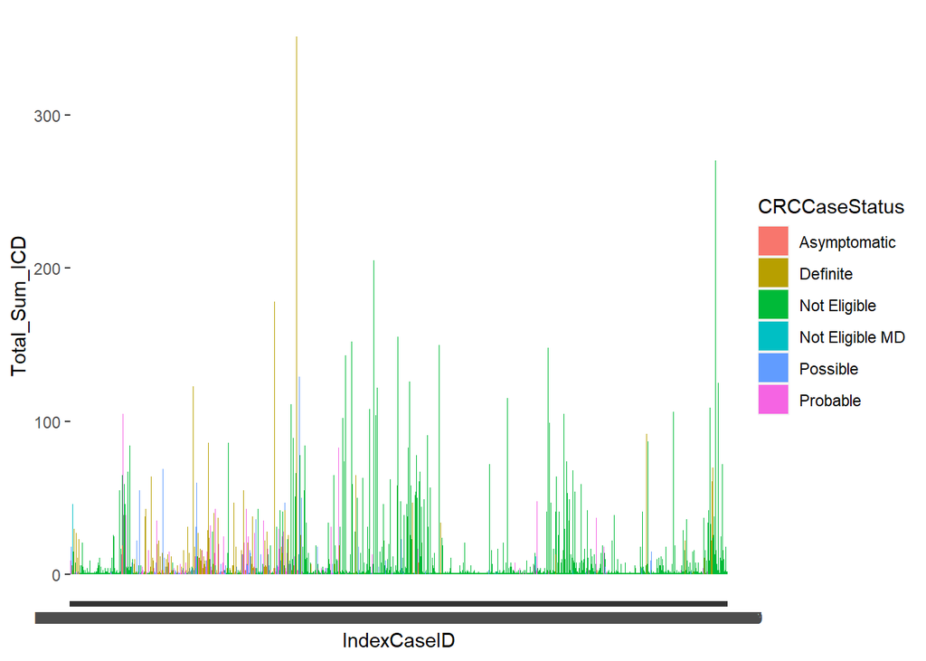

```r
data_using %>%
  ggplot(aes(x=IndexCaseID, y=Total_Sum_ICD)) +
  geom_col(aes(fill=CRCCaseStatus))
```

#### Total sum ICD historgram

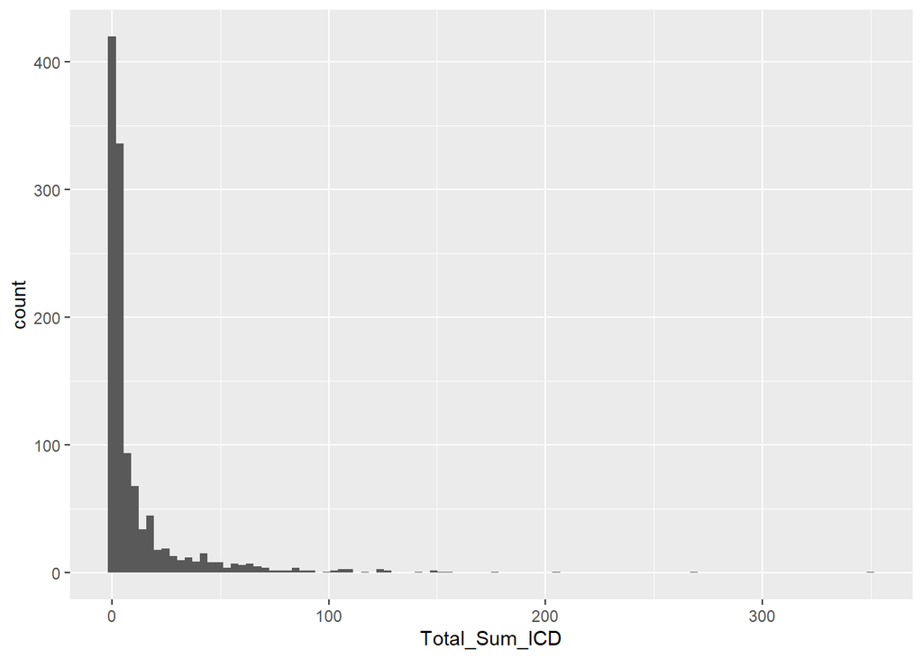

```r
data_using %>%
  ggplot(aes(x=Total_Sum_ICD)) +
  geom_histogram(bins = 100)
```

Is looking like I will need to make these into categories / thresholds

```r
sum_ICD_binned_data= data_using %>%
  mutate(greater_than_5 = if_else(Total_Sum_ICD > 5,
                                  1,
                                  0),
         greater_than_10 = if_else(Total_Sum_ICD >10,
                                   1,
                                   0),
         greater_than_15 = if_else(Total_Sum_ICD >15,
                                   1,
                                   0),
         greater_than_20 = if_else(Total_Sum_ICD >20,
                                   1,
                                   0)) %>%
  select(Total_Sum_ICD, greater_than_5, greater_than_10, greater_than_15, greater_than_20, filte_Def_Prob_Poss_1, CRCCaseStatus)
summary(sum_ICD_binned_data)
```

```
 Total_Sum_ICD    greater_than_5   greater_than_10  greater_than_15
 Min.   :  1.00   Min.   :0.0000   Min.   :0.0000   Min.   :0.0000
 1st Qu.:  1.00   1st Qu.:0.0000   1st Qu.:0.0000   1st Qu.:0.0000
 Median :  3.00   Median :0.0000   Median :0.0000   Median :0.0000
 Mean   : 12.17   Mean   :0.3593   Mean   :0.2475   Mean   :0.1932
 3rd Qu.: 10.00   3rd Qu.:1.0000   3rd Qu.:0.0000   3rd Qu.:0.0000
 Max.   :351.00   Max.   :1.0000   Max.   :1.0000   Max.   :1.0000
 greater_than_20  filte_Def_Prob_Poss_1 CRCCaseStatus
 Min.   :0.0000   Min.   :0.0000        Length:1180
 1st Qu.:0.0000   1st Qu.:0.0000        Class :character
 Median :0.0000   Median :0.0000        Mode  :character
 Mean   :0.1517   Mean   :0.2712
 3rd Qu.:0.0000   3rd Qu.:1.0000
 Max.   :1.0000   Max.   :1.0000
```

```r
sum_ICD_binned_data
```

```
# A tibble: 1,180 × 7
   Total_Sum_ICD greater_than_5 greater_than_10 greater_than_15 greater_than_20
           <dbl>          <dbl>           <dbl>           <dbl>           <dbl>
 1            15              1               1               0               0
 2             3              0               0               0               0
 3             4              0               0               0               0
 4             1              0               0               0               0
 5             1              0               0               0               0
 6            11              1               1               0               0
 7            26              1               1               1               1
 8            25              1               1               1               1
 9            17              1               1               1               0
10            65              1               1               1               1
# ℹ 1,170 more rows
# ℹ 2 more variables: filte_Def_Prob_Poss_1 <dbl>, CRCCaseStatus <chr>
```

## Sample logistic regression model

Rough initial logistic regression model.

```r
#filte_Def_Prob_Poss_1
log_model <- glm(filte_Def_Prob_Poss_1 ~ greater_than_5 + greater_than_10 + greater_than_15 + greater_than_20, data = sum_ICD_binned_data, family = binomial)
summary(log_model)
```

```
Call:
glm(formula = filte_Def_Prob_Poss_1 ~ greater_than_5 + greater_than_10 +
    greater_than_15 + greater_than_20, family = binomial, data = sum_ICD_binned_data)

Coefficients:
                Estimate Std. Error z value Pr(>|z|)
(Intercept)     -1.33100    0.08945 -14.880  < 2e-16 ***
greater_than_5   0.67175    0.20425   3.289  0.00101 **
greater_than_10  0.47119    0.31108   1.515  0.12985
greater_than_15  0.14723    0.38042   0.387  0.69874
greater_than_20 -0.54523    0.32556  -1.675  0.09398 .
---
Signif. codes:  0 '***' 0.001 '**' 0.01 '*' 0.05 '.' 0.1 ' ' 1

(Dispersion parameter for binomial family taken to be 1)

    Null deviance: 1379.3  on 1179  degrees of freedom
Residual deviance: 1334.0  on 1175  degrees of freedom
AIC: 1344

Number of Fisher Scoring iterations: 4
```

```r
#filte_Def_Prob_Poss_1
log_model_gt10 <- glm(filte_Def_Prob_Poss_1 ~ greater_than_10, data = sum_ICD_binned_data, family = binomial)
summary(log_model_gt10)
```

```
Call:
glm(formula = filte_Def_Prob_Poss_1 ~ greater_than_10, family = binomial,
    data = sum_ICD_binned_data)

Coefficients:
                Estimate Std. Error z value Pr(>|z|)
(Intercept)     -1.21621    0.07991 -15.219  < 2e-16 ***
greater_than_10  0.81360    0.14369   5.662  1.5e-08 ***
---
Signif. codes:  0 '***' 0.001 '**' 0.01 '*' 0.05 '.' 0.1 ' ' 1

(Dispersion parameter for binomial family taken to be 1)

    Null deviance: 1379.3  on 1179  degrees of freedom
Residual deviance: 1347.9  on 1178  degrees of freedom
AIC: 1351.9

Number of Fisher Scoring iterations: 4
```

#### EligibleYesNoPending

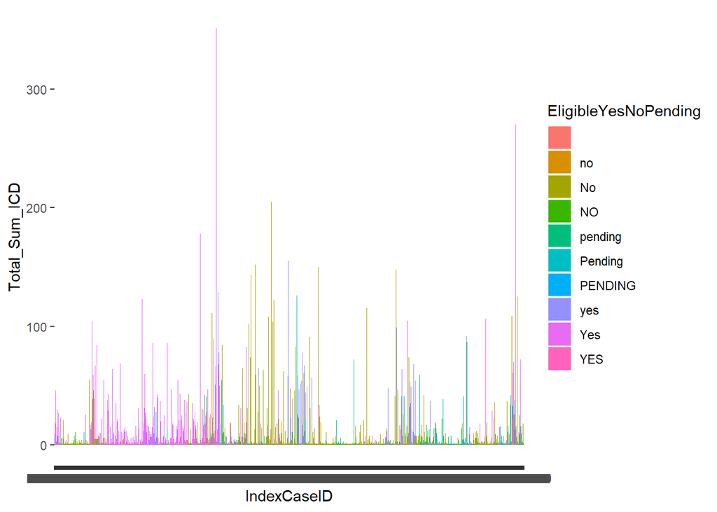

```r
data_using %>%
  ggplot(aes(x=IndexCaseID, y=Total_Sum_ICD)) +
  geom_col(aes(fill=EligibleYesNoPending))
```

### Exploring difference between ClinicalMDType and Clinical MDSubType

```r
table(data_using$ClinicalMDType)
```

```
                   Congenital         Distal Emery-Dreifuss           FSHD
           858              5              5              5             46
          LGMD     Likely ALS         MD NOS       Myotonic
            59              1              5            196
```

8 categories

```r
table(data_using$ClinicalMDSubType)
```

```
                                               Alpha-dystroglycan
                             869                                1
                         CMD NOS                           DM NOS
                               2                               65
                             DM1                              DM2
                             112                               19
                        EDMD NOS                      EDMD1 (EMD)
                               1                                1
                 EDMD2 (LMNA AD)                    EDMD4 (SYNE1)
                               2                                1
                          FSHD 1                           FSHD 2
                              15                                1
                        FSHD NOS                      Laminopathy
                              30                                2
         LGMD Dystroglycanopathy                         LGMD NOS
                               2                               37
                 LGMD1E (DNAJB6)                    LGMD1G (4q21)
                               1                                1
          LGMD2A (Calpainopathy)         LGMD2B (Dysferlinopathy)
                               2                                3
LGMD2D (Alpha-sarcoglycanopathy)  LGMD2E (Beta-sarcoglycanopathy)
                               4                                1
                 LGMD2H (TRIM32)                    LGMD2I (FKRP)
                               1                                4
            LGMD2L (ANO5; 11p14)
                               3
```

24 categories. The number of each is rather small for those with 10 or less participants

### Visualizing Filter_exclude_nonCRC

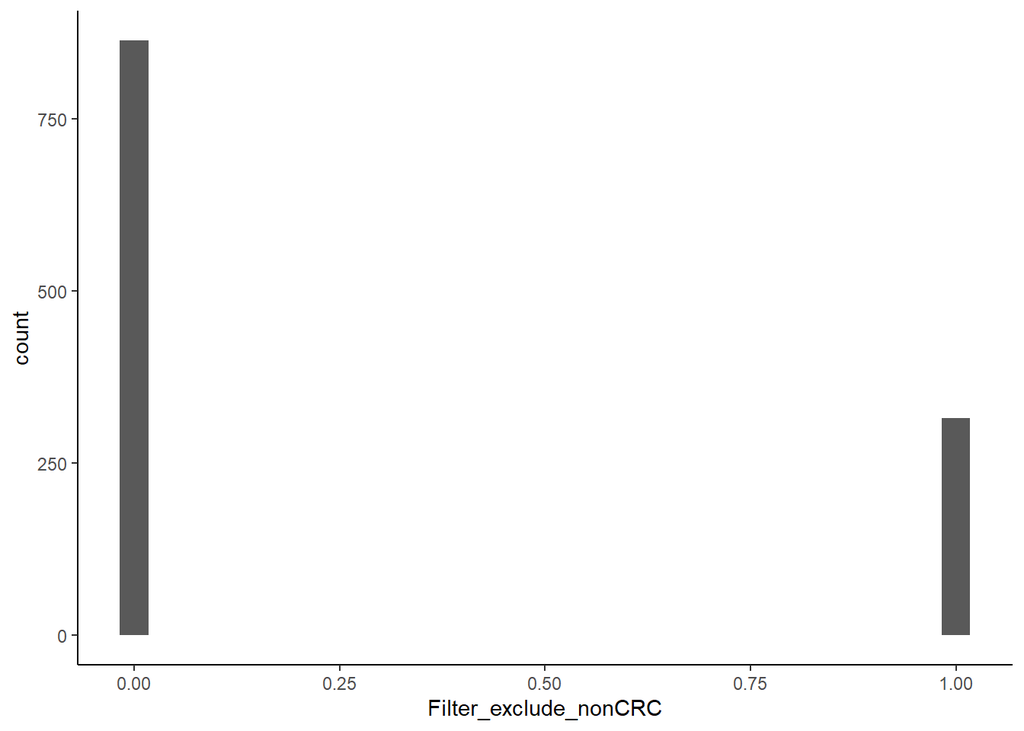

```r
data_using %>%
  ggplot(aes(x=Filter_exclude_nonCRC), color = 'blue') +
  geom_histogram() +
  theme_classic()
```

## EDA V21

```
[1] "Number of rows in dataset is 560"
```

```
[1] "Number of columns in dataset is 22"
```

```
 [1] "IndexCaseID"        "Total_Sum_ICD"      "Sum_359"
 [4] "Sum_359_1"          "Sum_359_21"         "Sum_G71_0"
 [7] "Sum_G71_00"         "Sum_G71_01"         "Sum_G71_02"
[10] "Sum_G71_09"         "Sum_G71_11"         "CRCCaseStatus"
[13] "ClinicalMDType"     "ClinicalMDSubType"  "IndexCaseRace"
[16] "IndexCaseSex"       "IndexCaseSexOther"  "IndexCaseEthnicity"
[19] "CaseStatus_Num"     "DefProbPoss"        "DefProb_Poss"
[22] "DefProb_Else"
```

```
[1] "Displaying quick table of DefProbPoss"
```

```
5.29980882362664e-315 2.12198984636742e-314                     1
                    2                     6                    87
```

```
[1] "Displaying quick table of DefProb_Poss"
```

```
5.29980882362664e-315 2.12198984636742e-314                     1
                    2                     6                    82
                    2
                    5
```

```
[1] "Displaying DefProb_Else"
```

```
2.01204996642363e-76 2.01205095507271e-76 1.31861706599539e-71
                   1                    4                    1
1.31861706620623e-71 1.31861771391645e-71                    1
                   1                    1                   82
                   2
                   9
```

```
[1] "I don't think it's any of these"
```

```
[1] "Checking CRCCaseStatus"
```

```
      5  99   1   2   3   4  43  48   5
465   1   1   2  78   2   5   1   1   4
```

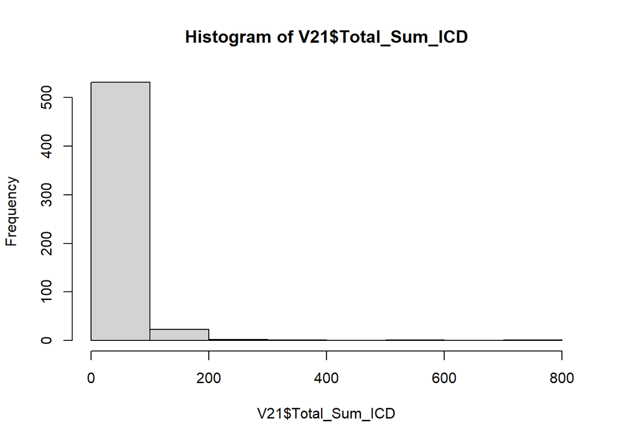

```
  0%   5%  10%  15%  20%  25%  30%  35%  40%  45%  50%  55%  60%  65%  70%  75%
   1    1    1    1    1    1    1    1    2    2    3    3    4    6    8   10
 80%  85%  90%  95% 100%
  14   21   35   59  351
```

```
           0%            5%           10%           15%           20%
5.299809e-315  1.000000e+00  1.000000e+00  1.000000e+00  1.000000e+00
          25%           30%           35%           40%           45%
 1.000000e+00  1.000000e+00  2.000000e+00  2.000000e+00  3.000000e+00
          50%           55%           60%           65%           70%
 3.000000e+00  4.000000e+00  6.000000e+00  8.000000e+00  1.100000e+01
          75%           80%           85%           90%           95%
 1.600000e+01  2.440000e+01  3.700000e+01  5.920000e+01  9.850000e+01
         100%
 7.940000e+02
```

V21 appears very different than V20.

## Initial request for service highlights

What is your research question? **Does the number of patient encounters with muscular dystrophy-specific ICD codes predict whether they truly meet rigorous criteria for the diagnosis of muscular dystrophy?**

Clearly state your hypothesis(es). A higher number of appro**priate ICD codes linked to specific encounters makes it more likely that an individual has muscular dystrophy.**

Provide dates of any deadlines that apply to this project (e.g. grant applications, IRB deadlines) Would like to complete analysis in January or February of 2024 but no hard deadlines. **At most a 4 week turn around.**

https://3.basecamp.com/5125554/buckets/35608067/documents/6923476106

## Initial meeting on 1/10/24

plot 1: X-axis = Total_Sum_ICD(binned), y-axis = count, color coded by CRC Case Status

plot 2: X-axis = number of encounters with relevant ICD codes, y-axis = count, color coded by Case Status.

Thoughts from meeting discussion…

- With a cutoff we can calculate the odds ratio -more or less than 10 (if 10 is the cutoff)
- Outcome looking for -if there are more than 10 encounters with the right ICD code- would like to prioritize those with a higher probability threshold
- For 1 threshold we can look at all the individuals above that threshold and calculate the odds ration and look at the probability of success, and then we increase the threshold and calculate the proportion/ratio and at the end we should have an odds ratio
- No statistical conclusions but have statistical methods and conclusions on whu we select these thresholds